# SAP - Second auditory exercise

Case study *FIFA 19 data*: Statistical inference for numerical and categorical data

Tessa Bauman, Stjepan Begušić, David Bojanić, Krunoslav Jurčić, Tomislav Kovačević, Andro Merćep

16.11.2022.

## Introduction

The second exercise deals with hypothesis testing and calculating the $p$-value on real world examples for numerical data (using the $t$-test, $\chi^2$-test and $F$-test) and categorical data (using the $\chi^2$-test and Fisher-Irwin exact test).

## Case study: *FIFA 19*

[Kaggle.com](https://www.kaggle.com/) is a web page intended for hosting competitions on various machine learning and statistical data analysis tasks. Other than hosting competitions however, Kaggle offers researches many freely available datasets, their analysis, computer science courses and computing power.

As with any new dataset we analyze, it is important to know the context of the data so we can correctly interpret the final results! Therefore, before answering any questions or testing any hypothesis, we use the tools of descriptive analysis to get acquainted with our dataset.

# Descriptive analysis

Firstly, we load the necessary R packages to facilitate our analysis.

```r
library(dplyr)
```

Let’s load the FIFA 2019 dataset.

```r
fifa19 = read.csv("datasets/players_19.csv")
dim(fifa19)
```

```
## [1] 17770   104
```

As we can see, the data is comprised of 17770 players and 104 variables that describe them.

What are the variables?

```r
names(fifa19)
```

```
##   [1] "sofifa_id"                  "player_url"
##   [3] "short_name"                 "long_name"
##   [5] "age"                        "dob"
##   [7] "height_cm"                  "weight_kg"
##   [9] "nationality"                "club"
##  [11] "overall"                    "potential"
##  [13] "value_eur"                  "wage_eur"
##  [15] "player_positions"           "preferred_foot"
##  [17] "international_reputation"   "weak_foot"
##  [19] "skill_moves"                "work_rate"
##  [21] "body_type"                  "real_face"
##  [23] "release_clause_eur"         "player_tags"
##  [25] "team_position"              "team_jersey_number"
##  [27] "loaned_from"                "joined"
##  [29] "contract_valid_until"       "nation_position"
```

[output cut: 37 more lines]

The players are described with various general variables (like their name, age, the football club they are playing for, etc.) and “football” variables (like the attack, defense and other characteristics).

```r
View(fifa19)
```

We can immediately see that not all of the dataset variables are equally useful. For example, the variable “player_url” is the web url linking the football player with its sofifa page from where the data was scraped. We cannot use such a variable to do any statistical analysis. Therefore, as is often recommended, we are going to eliminate the variable (along with other similarly unnecessary variables) to create a more concise and uncluttered dataset.

```r
fifa19 = select(fifa19, -c("player_url","long_name","real_face","player_tags","loaned_from","player_traits"))
dim(fifa19)
```

```
## [1] 17770    98
```

We are left with 98 variables that describe our players.

How do our variables behave?

```r
summary(fifa19)
```

```
##    sofifa_id       short_name             age            dob
##  Min.   :   164   Length:17770       Min.   :16.00   Length:17770
##  1st Qu.:199803   Class :character   1st Qu.:21.00   Class :character
##  Median :221350   Mode  :character   Median :25.00   Mode  :character
##  Mean   :213798                      Mean   :25.19
##  3rd Qu.:235968                      3rd Qu.:28.00
##  Max.   :246063                      Max.   :45.00
##
##    height_cm       weight_kg      nationality            club
##  Min.   :154.0   Min.   : 50.00   Length:17770       Length:17770
##  1st Qu.:176.0   1st Qu.: 70.00   Class :character   Class :character
##  Median :181.0   Median : 75.00   Mode  :character   Mode  :character
##  Mean   :181.3   Mean   : 75.31
##  3rd Qu.:186.0   3rd Qu.: 80.00
##  Max.   :205.0   Max.   :110.00
##
##     overall        potential       value_eur            wage_eur
##  Min.   :47.00   Min.   :48.00   Min.   :        0   Min.   :     0
##  1st Qu.:62.00   1st Qu.:67.00   1st Qu.:   300000   1st Qu.:  1000
##  Median :66.00   Median :71.00   Median :   675000   Median :  3000
##  Mean   :66.24   Mean   :71.38   Mean   :  2440756   Mean   :  9956
##  3rd Qu.:71.00   3rd Qu.:75.00   3rd Qu.:  2000000   3rd Qu.:  9000
##  Max.   :94.00   Max.   :95.00   Max.   :118500000   Max.   :565000
##
##  player_positions   preferred_foot     international_reputation   weak_foot
##  Length:17770       Length:17770       Min.   :1.000            Min.   :1.000
##  Class :character   Class :character   1st Qu.:1.000            1st Qu.:3.000
##  Mode  :character   Mode  :character   Median :1.000            Median :3.000
##                                        Mean   :1.118            Mean   :2.946
##                                        3rd Qu.:1.000            3rd Qu.:3.000
##                                        Max.   :5.000            Max.   :5.000
##
##   skill_moves     work_rate          body_type         release_clause_eur
##  Min.   :1.000   Length:17770       Length:17770       Min.   :    13000
##  1st Qu.:2.000   Class :character   Class :character   1st Qu.:   525000
##  Median :2.000   Mode  :character   Mode  :character   Median :  1200000
##  Mean   :2.347                                         Mean   :  4645685
##  3rd Qu.:3.000                                         3rd Qu.:  3500000
##  Max.   :5.000                                         Max.   :228100000
##                                                        NA's   :1513
```

[output cut: 153 more lines]

```
##  Length:17770       Length:17770       Length:17770       Length:17770
##  Class :character   Class :character   Class :character   Class :character
##  Mode  :character   Mode  :character   Mode  :character   Mode  :character
##
##
##
##
##       cb                rcb                 rb
##  Length:17770       Length:17770       Length:17770
##  Class :character   Class :character   Class :character
##  Mode  :character   Mode  :character   Mode  :character
##
##
##
##
```

```r
sapply(fifa19, class)
```

```
##                  sofifa_id                 short_name
##                  "integer"                "character"
##                        age                        dob
##                  "integer"                "character"
##                  height_cm                  weight_kg
##                  "integer"                  "integer"
##                nationality                       club
##                "character"                "character"
##                    overall                  potential
##                  "integer"                  "integer"
##                  value_eur                   wage_eur
##                  "integer"                  "integer"
##           player_positions             preferred_foot
##                "character"                "character"
##   international_reputation                  weak_foot
##                  "integer"                  "integer"
##                skill_moves                  work_rate
##                  "integer"                "character"
##                  body_type         release_clause_eur
##                "character"                  "integer"
##              team_position         team_jersey_number
##                "character"                  "integer"
##                     joined       contract_valid_until
##                "character"                  "integer"
##            nation_position       nation_jersey_number
##                "character"                  "integer"
##                       pace                   shooting
##                  "integer"                  "integer"
##                    passing                  dribbling
##                  "integer"                  "integer"
##                  defending                     physic
##                  "integer"                  "integer"
##                  gk_diving                gk_handling
##                  "integer"                  "integer"
##                 gk_kicking                gk_reflexes
##                  "integer"                  "integer"
##                   gk_speed             gk_positioning
##                  "integer"                  "integer"
##         attacking_crossing        attacking_finishing
##                "character"                "character"
```

[output cut: 43 more lines]

```
##                "character"                "character"
##                        lcm                         cm
##                "character"                "character"
##                        rcm                         rm
##                "character"                "character"
##                        lwb                        ldm
##                "character"                "character"
##                        cdm                        rdm
##                "character"                "character"
##                        rwb                         lb
##                "character"                "character"
##                        lcb                         cb
##                "character"                "character"
##                        rcb                         rb
##                "character"                "character"
```

The dataset is mostly comprised of “integer” and “character” data.

```r
for (col_name in names(fifa19)){
  if (sum(is.na(fifa19[,col_name])) > 0){
    cat('Number of missing values for variable ',col_name, ': ', sum(is.na(fifa19[,col_name])),'\n')
  }
}
```

```
## Number of missing values for variable  release_clause_eur :  1513
## Number of missing values for variable  team_jersey_number :  223
## Number of missing values for variable  contract_valid_until :  223
## Number of missing values for variable  nation_jersey_number :  16666
## Number of missing values for variable  pace :  1986
## Number of missing values for variable  shooting :  1986
## Number of missing values for variable  passing :  1986
## Number of missing values for variable  dribbling :  1986
## Number of missing values for variable  defending :  1986
## Number of missing values for variable  physic :  1986
## Number of missing values for variable  gk_diving :  15784
## Number of missing values for variable  gk_handling :  15784
## Number of missing values for variable  gk_kicking :  15784
## Number of missing values for variable  gk_reflexes :  15784
## Number of missing values for variable  gk_speed :  15784
## Number of missing values for variable  gk_positioning :  15784
```

```r
cat('\n Dimension of the dataset: ', dim(fifa19))
```

```
##
##  Dimension of the dataset:  17770 98
```

We can notice that a big portion of variables starting with the prefix “gk_*” are missing. This does make sense and does not point to corrupted (or badly acquired) data since these variables describe the goalkeeper characteristics. Most players are not goalkeepers, so they are naturally never evaluated as one. Therefore, we will not eliminate these variables.

On the other hand, the variable “nation_jersey_number” has 93% of missing values which means that we have a lot of missing data. We eliminate this variable to, again, create a more clear and concise dataset.

The remaining variables do not have a lot of missing values.

```r
fifa19 = select(fifa19, -c("nation_jersey_number"))
dim(fifa19)
```

```
## [1] 17770    97
```

Let’s now examine the variables we will later use to pose our hypotheses and answer several questions. We focus first on the numerical variables.

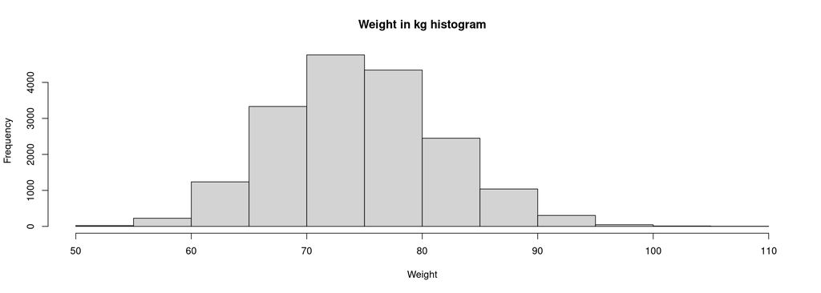

```r
hist(fifa19$weight_kg,main='Weight in kg histogram', xlab='Weight', ylab='Frequency')
```

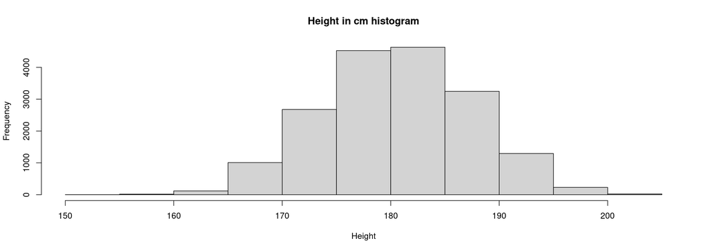

```r
hist(fifa19$height_cm,main='Height in cm histogram', xlab='Height', ylab='Frequency')
```

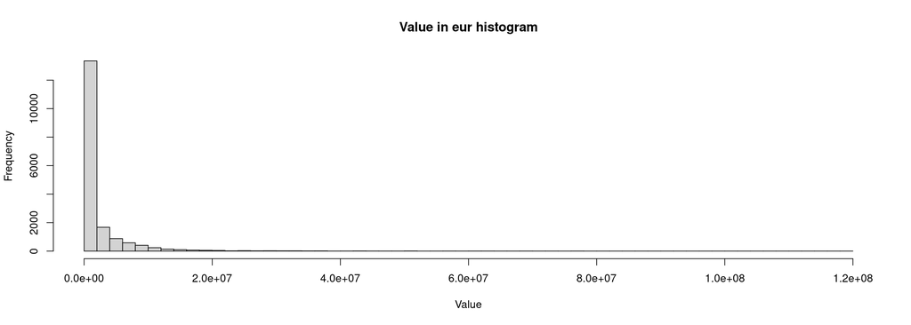

```r
hist(fifa19$value_eur,main='Value in eur histogram',xlab='Value',ylab='Frequency', breaks=50)
```

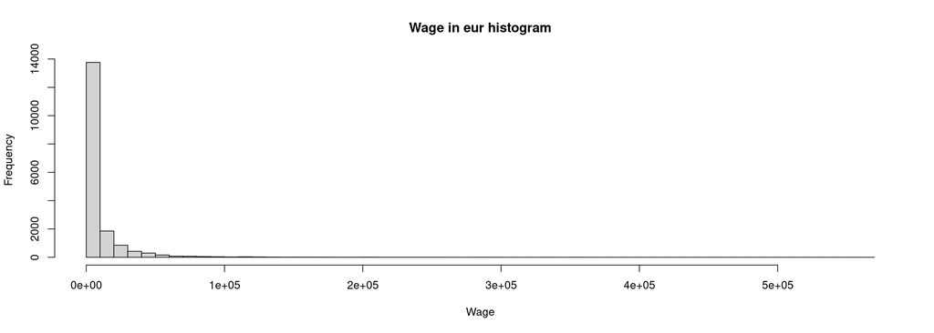

```r
hist(fifa19$wage_eur,main='Wage in eur histogram',xlab='Wage',ylab='Frequency', breaks=50)
```

The distribution of the value and wage of the players is very skewed. Let’s see if the log transformation brings the data closer to a normal distribution.

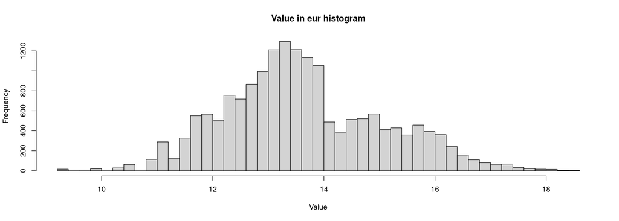

```r
hist(log(fifa19$value_eur),main='Value in eur histogram',xlab='Value',ylab='Frequency', breaks=50)
```

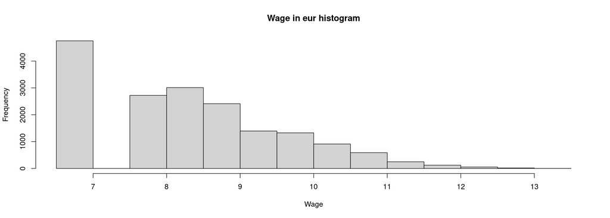

```r
hist(log(fifa19$wage_eur),main='Wage in eur histogram',xlab='Wage',ylab='Frequency', breaks=20)
```

The distribution of the value of the players now resembles the normal distribution, whereas the wage is still far away from it.

Let’s examine the categorical variables.

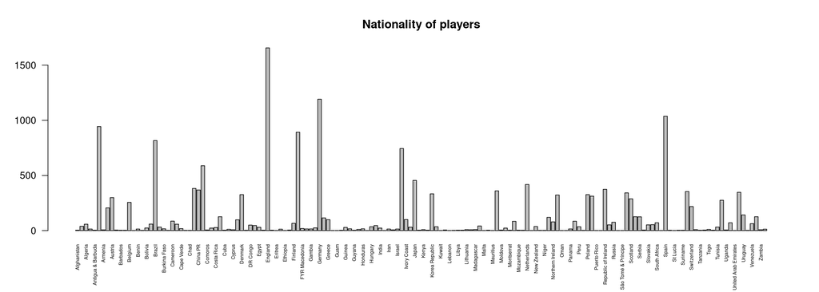

```r
barplot(table(fifa19$nationality),las=2,cex.names=.5,main='Nationality of players')
```

```r
print('Players preferred kicking foot: ')
```

```
## [1] "Players preferred kicking foot: "
```

```r
table(fifa19$preferred_foot)
```

```
##
##  Left Right
##  4131 13639
```

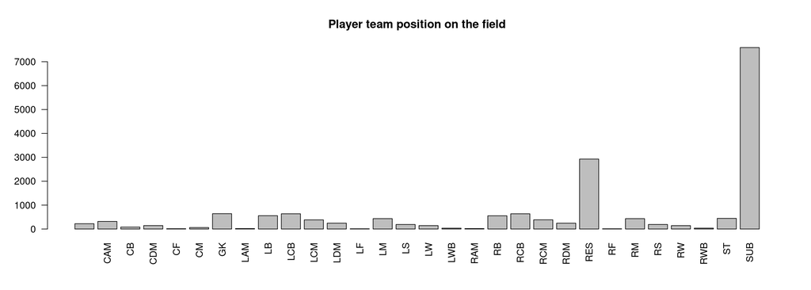

```r
barplot(table(fifa19$team_position),las=2,main='Player team position on the field')
```

We notice that the variable “team_position” contains players without any position.

```r
table(fifa19$team_position)
```

```
##
##       CAM   CB  CDM   CF   CM   GK  LAM   LB  LCB  LCM  LDM   LF   LM   LS   LW
##  223  318   83  144   13   62  642   19  558  638  384  247   10  435  190  143
##  LWB  RAM   RB  RCB  RCM  RDM  RES   RF   RM   RS   RW  RWB   ST  SUB
##   36   19  555  638  387  246 2928   10  434  191  142   37  445 7593
```

More concretely, there are 223 players with no position in the team. This is something we need to take into consideration for later analysis.

After we have explored our dataset, we can try to answer some questions using the tools we have learned and R.

## Are Croatian players taller than Spanish players?

```r
croatian_players = fifa19[fifa19$nationality == "Croatia",]
spanish_players = fifa19[fifa19$nationality == "Spain",]
```

```r
cat('Average height of croatian players ', mean(croatian_players$height_cm),'\n')
```

```
## Average height of croatian players  185.3095
```

```r
cat('Average height of spanish players ',
    mean(spanish_players$height_cm), '\n')
```

```
## Average height of spanish players  180.6114
```

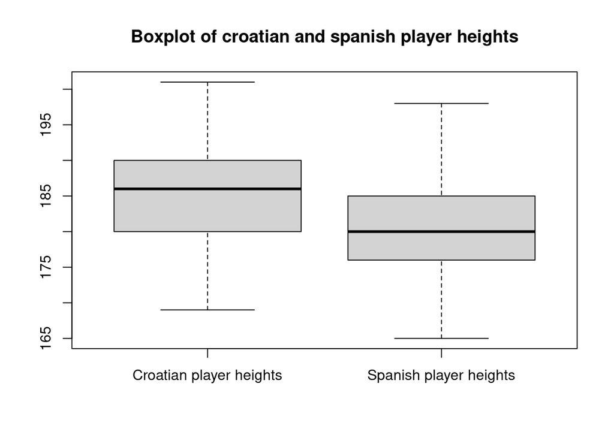

```r
boxplot(croatian_players$height_cm, spanish_players$height_cm,
        names = c('Croatian player heights','Spanish player heights'),
        main='Boxplot of croatian and spanish player heights')
```

There are some indications that the Croatian players could be taller than the Spanish ones.

We can use the $t$-test to answer our question. First, however, we need to check if our test has any assumptions over the data we are testing.

### Testing the equality of means from two samples

Let $X_1^1, X_1^2, \ldots, X_1^{n_1}$ and $X_2^1, X_2^2, \ldots, X_2^{n_2}$ be two independent random samples from the normal distribution with means $\mu_1$, $\mu_2$ and unknown, but equal, variances $\sigma$. The joint variance of the sample can be found as the weighted average of the sample variances $S_{X_1}$ i $S_{X_2}$:

$$S_X^2 = \frac{1}{n_1 + n_2 - 2} [(n_1 -
1) S_{X_1}^2 + (n_2 - 1) S_{X_2}^2].$$

The random variable
$$Z = \frac{\bar{X}_1
- \bar{X}_2 - (\mu_1 - \mu_2)}{\sigma \sqrt{\frac{1}{n_1} +
\frac{1}{n_2}}}$$

has a unit normal distribution. The random variable
$$W^2 = \frac{(n_1 - 1) S_{X_1}^2 + (n_2 - 1)
S_{X_2}^2}{\sigma^2}$$

has a $\chi^2$ distribution with $n_1 + n_2 - 2$ degrees of freedom. Therefore, the random variable
$$T = \frac{Z
\sqrt{n_1 + n_2 - 2}}{W} = \frac{\bar{X}_1 - \bar{X}_2 - (\mu_1 -
\mu_2)}{S_X \sqrt{\frac{1}{n_1} + \frac{1}{n_2}}}$$

has an exact $t$-distribution with $n_1 + n_2 - 2$ degrees of freedom.

If we have two independent and normally distributed samples, but this time with different variances, we can use the test statistic

$$T' = \frac{\bar{X}_1 - \bar{X}_2 -
(\mu_1 - \mu_2)}{\sqrt{\frac{s_{X_1}^2}{n_1} +
\frac{s_{X_2}^2}{n_2}}}$$

that has an approximate $t$-distribution with $v$ degrees of freedom
$$v = \frac{(s_{X_1}^2/n_1+ s_{X_2}^2 /
n_2)^2}{(s_{X_1}^2/n_1)^2 / (n_1 - 1) + (s_{X_2}^2/n_2)^2 / (n_2 -
1)}$$
where
$$s_{X_i}^2 = \frac{1}{n_i
- 1} \sum_{j=1}^{n_i} (X_i^j - \bar{X_i})^2$$
for $i=1,2$.

The hypothesis can then be written as:
$$\begin{aligned}
H_0&: \mu_1 = \mu_2 \\
H_1&: \mu_1 < \mu_2 \quad \text{,} \quad \mu_1 > \mu_2 \quad
\text{,} \quad \mu_1 \neq \mu_2
\end{aligned}$$

These tests are implemented in the function `t.test()` in R.

To run the test, we need to check the independence and normality assumptions of the $t$-test. Since we are considering two samples from two different countries (Croatia and Spain) we can assume their independence. To check the normality assumption we can make use of: a histogram plot, a Q-Q plot or the KS-test (the KS-test tests if a given sample comes from a queried distribution).

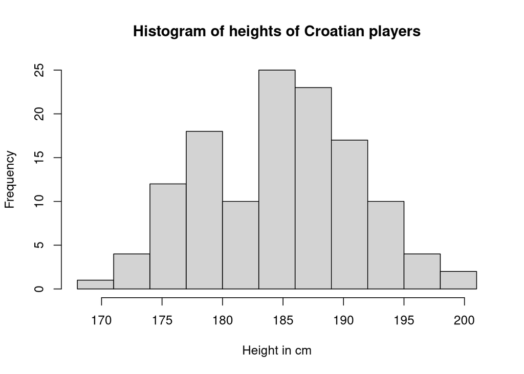

```r
hist(croatian_players$height_cm,
     breaks=seq(min(croatian_players$height_cm)-1,max(croatian_players$height_cm)+1,3),
     main='Histogram of heights of Croatian players',
     xlab='Height in cm')
```

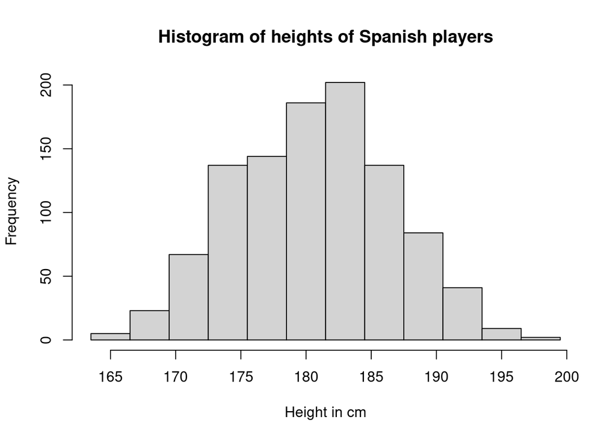

```r
hist(spanish_players$height_cm,
     breaks=seq(min(spanish_players$height_cm)-1.5,max(spanish_players$height_cm)+1.5,3),
     main='Histogram of heights of Spanish players',
     xlab='Height in cm')
```

The bell-shaped curve in the histograms point to normally distributed data. We can also check the normality of the data using the Q-Q plot.

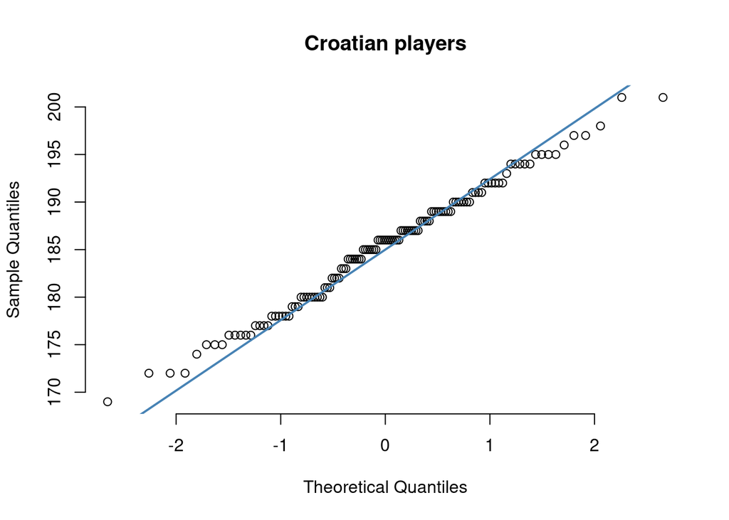

```r
qqnorm(croatian_players$height_cm, pch = 1, frame = FALSE,main='Croatian players')
qqline(croatian_players$height_cm, col = "steelblue", lwd = 2)
```

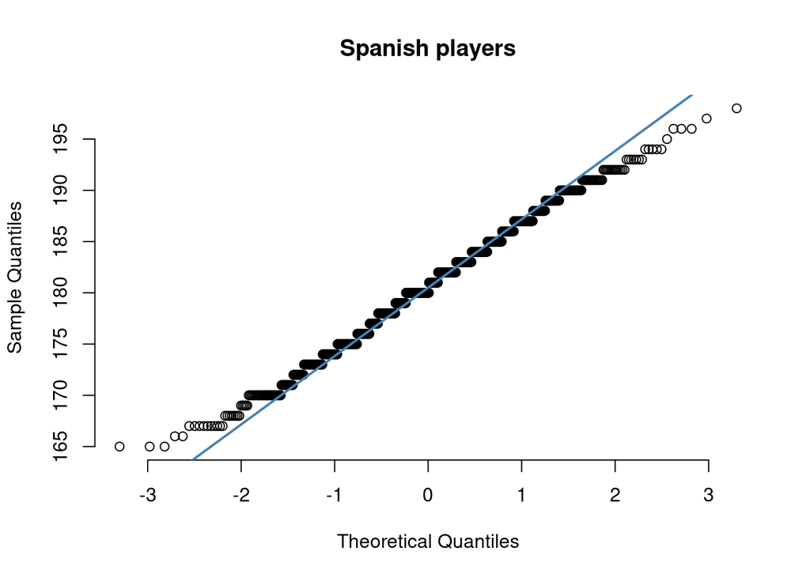

```r
qqnorm(spanish_players$height_cm, pch = 1, frame = FALSE,main='Spanish players')
qqline(spanish_players$height_cm, col = "steelblue", lwd = 2)
```

The sample quantiles seem to follow the theoretical quantiles of a normal distribution.

Under the condition that our data now satisfies our assumptions, we can continue with the $t$-test to check if the Croatian players are taller than the Spanish ones.

Which of the two tests mentioned above do we use? We need to analyze the variances of our samples.

```r
var(croatian_players$height_cm)
```

```
## [1] 42.96743
```

```r
var(spanish_players$height_cm)
```

```
## [1] 36.67026
```

Are the variances significantly different?

### Testing the equality of two variances

Let $X_1^1, X_1^2, \ldots X_1^{n_1}$ and $X_2^1, X_2^2, \ldots, X_2^{n_2}$ be two independent and random samples from the normal distribution with variances $\sigma_1^2$ and $\sigma_2^2$. Then, the random variable
$$F = \frac{S_{X_1}^2 / \sigma_1^2}{S_{X_2}^2
/ \sigma_2^2}$$

follows a Fisher distribution with $(n_1 - 1, n_2 - 1)$ degrees of freedom, where:
$$S_{X_1}^2 = \frac{1}{n_1 - 1} \sum_{i = 1}^{n_1}
(X_1^i - \bar{X}_1)^2, \quad S_{X_2}^2 = \frac{1}{n_2 - 1} \sum_{i =
1}^{n_2} (X_2^i - \bar{X}_2)^2.$$
The hypothesis of the test are:
$$\begin{aligned}
H_0&: \sigma_1^2 = \sigma_2^2 \\
H_1&: \sigma_1^2 < \sigma_2^2 \quad \text{,} \quad \sigma_1^2
> \sigma_2^2 \quad \text{,} \quad \sigma_1^2 \neq \sigma_2^2
\end{aligned}$$

This tests is implemented in the function `var.test()` in R.

Let’s test the variance equality of our Croatian and Spanish players.

```r
var.test(croatian_players$height_cm, spanish_players$height_cm)
```

```
##
##  F test to compare two variances
##
## data:  croatian_players$height_cm and spanish_players$height_cm
## F = 1.1717, num df = 125, denom df = 1036, p-value = 0.2141
## alternative hypothesis: true ratio of variances is not equal to 1
## 95 percent confidence interval:
##  0.9128465 1.5459734
## sample estimates:
## ratio of variances
##           1.171724
```

Comparing the $p$-value of $0.2141$ with our significance level of 5%, we are not going to reject the $H_0$ hypothesis which states that the variances of the height of Croatian and Spanish players are the same.

We can now run the $t$-test with the assumption of equal variances.

```r
# The order of samples in the function 't.test()' matters!
t.test(croatian_players$height_cm, spanish_players$height_cm, alt = "greater", var.equal = TRUE)
```

```
##
##  Two Sample t-test
##
## data:  croatian_players$height_cm and spanish_players$height_cm
## t = 8.1485, df = 1161, p-value = 4.728e-16
## alternative hypothesis: true difference in means is greater than 0
## 95 percent confidence interval:
##  3.749018      Inf
## sample estimates:
## mean of x mean of y
##  185.3095  180.6114
```

Because of a very small $p$-value, we reject the $H_0$ hypothesis that states that the Croatian and Spanish players have equal heights on average. Therefore, we can say that the Croatian players are on average taller than the Spanish players.

## Did the Spanish players improve from season 2019 to season 2020?

As previously noted, our dataset contains the statistics of players from the year 2015 until the year 2020. We can use the data to check for any improvements of players from season to season. We notice however, that the samples we would like to compare (Spanish players from 2019 and 2020) are comprised of the same data, since the same players are located in both the FIFA 2019 and FIFA 2020 dataset. This means that, if would like to compare the average quality of the players, we cannot use the the $t$-test, since the independence assumption would be violated. Therefore, we need a $t$-test that takes into consideration the data dependence between samples.

## Paired data

Let the tuple $(X_1^i, X_2^i)_{i=1}^n$ be a repeated measurement of $n$ different examples representing our two dependent samples and $D_i$ the random variable of their difference
$$D_i =
X_1^i - X_2^i$$
.

The random variables $X_1^i$ and $X_2^i$ are dependent:
$$\sigma_D^2 = Var(D_i) = Var(X_1^i - X_2^i) =
\sigma_1^2 + \sigma_2^2 - 2 Cov(X_1^i,X_2^i).$$

If we denote with
$$X_1^i = \mu_1 +
\eta_1^i , \quad X_2^i = \mu_2 + \eta_2^i,$$
we get
$$\sigma_D^2 = Var(\eta_1^i) + Var(\eta_2^i) - 2
Cov(\eta_1^i,\eta_2^i).$$
The test statistics is then given as:
$$T = \frac{\bar{D} - \mu_D}{S_d /
\sqrt{n}}$$
and the hypothesis are:
$$\begin{aligned}H_0&: \mu_D = d_0 \\
H_1&: \mu_D < d_0 \quad \text{,} \quad \mu_D > d_0 \quad
\text{,} \quad \mu_d \neq d0
\end{aligned}$$

The $t$-test for the paired data is also implemented in the function `t.test()` by adding a parameter `paired=True`.

Let’s first load the 2020 data.

```r
fifa20 = read.csv("datasets/players_20.csv")
dim(fifa20)
```

```
## [1] 18278   104
```

```r
names(fifa20)
```

```
##   [1] "sofifa_id"                  "player_url"
##   [3] "short_name"                 "long_name"
##   [5] "age"                        "dob"
##   [7] "height_cm"                  "weight_kg"
##   [9] "nationality"                "club"
##  [11] "overall"                    "potential"
##  [13] "value_eur"                  "wage_eur"
##  [15] "player_positions"           "preferred_foot"
##  [17] "international_reputation"   "weak_foot"
##  [19] "skill_moves"                "work_rate"
##  [21] "body_type"                  "real_face"
##  [23] "release_clause_eur"         "player_tags"
##  [25] "team_position"              "team_jersey_number"
##  [27] "loaned_from"                "joined"
##  [29] "contract_valid_until"       "nation_position"
```

[output cut: 37 more lines]

We merge the 2019 and 2020 data using the unique key for each player:

```r
merged_df = merge(fifa19, fifa20, by="sofifa_id", suffixes = c(".19",".20"))
```

To see if the players improved from 2019 to 2020, we can use the “overall score” variable that attributes an overall quality of each player in the given season.

First, we check the data normality using the histograms and Q-Q plots:

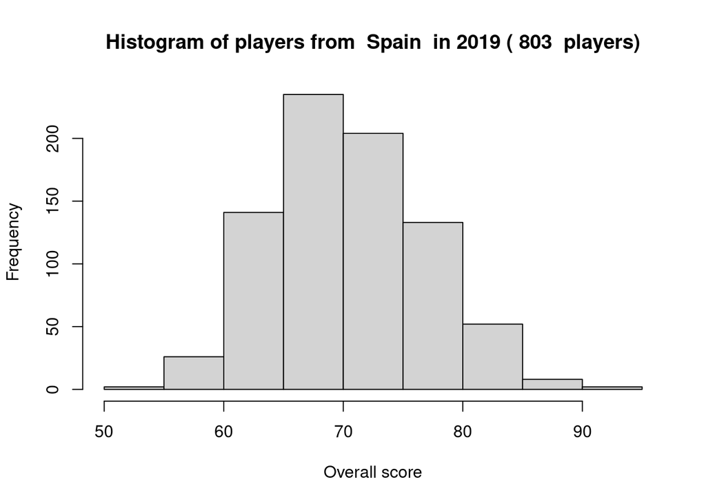

```r
country = 'Spain'

len = length(merged_df[merged_df$nationality.19 == country,]$overall.19 -  merged_df[merged_df$nationality.19 == country,]$overall.20)

hist(merged_df[merged_df$nationality.19 == country,]$overall.19,
     main=paste('Histogram of players from ',country,' in 2019 (',len,' players)'),
     xlab='Overall score')
```

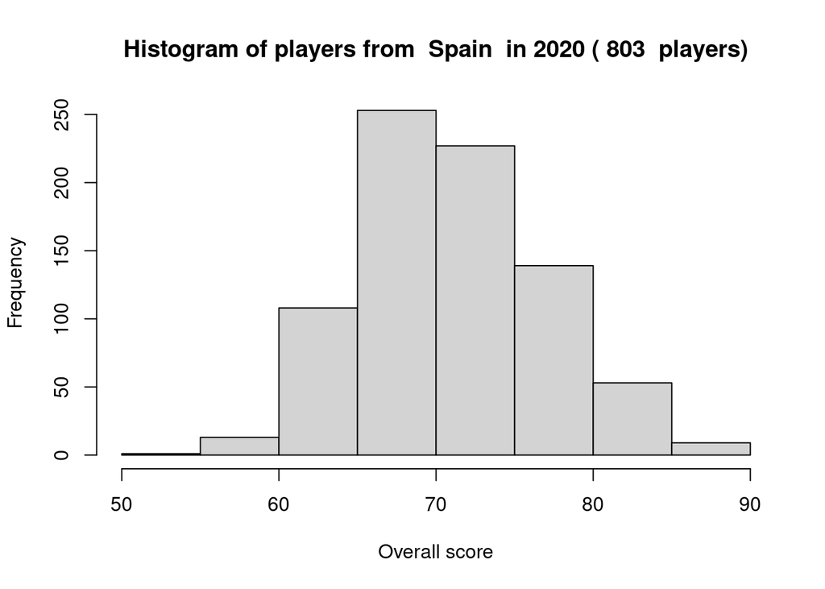

```r
hist(merged_df[merged_df$nationality.19 == country,]$overall.20,
     main=paste('Histogram of players from ',country,' in 2020 (',len,' players)'),
     xlab='Overall score')
```

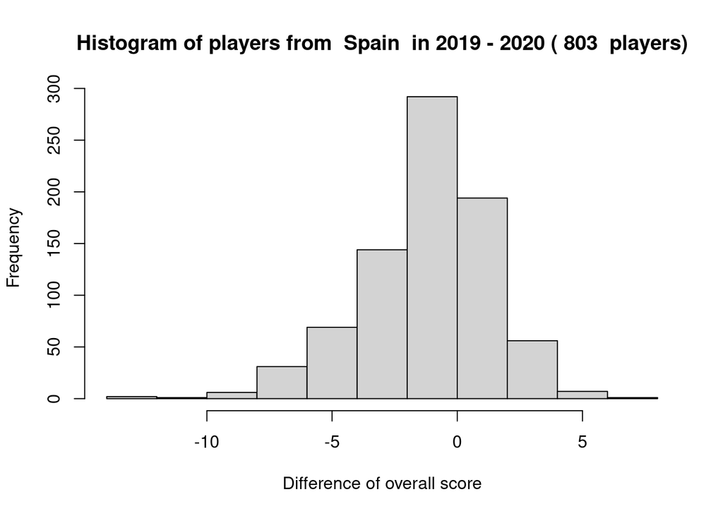

```r
hist(merged_df[merged_df$nationality.19 == country,]$overall.19 -
       merged_df[merged_df$nationality.19 == country,]$overall.20,
     main=paste('Histogram of players from ',country,' in 2019 - 2020 (',len,' players)'),
     xlab='Difference of overall score')
```

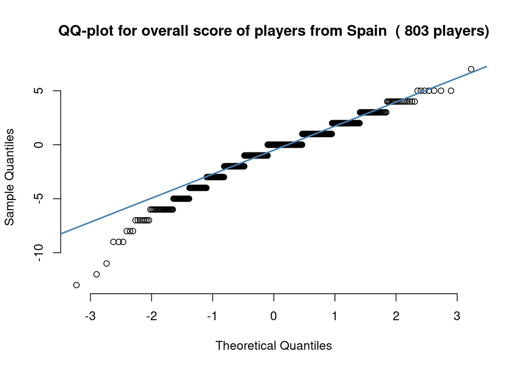

```r
qqnorm(merged_df[merged_df$nationality.19 == country,]$overall.19 - merged_df[merged_df$nationality.19 == country,]$overall.20,
       pch = 1,
       frame = FALSE,
       main=paste('QQ-plot for overall score of players from',country,' (',len,'players)'))
qqline(merged_df[merged_df$nationality.19 == country,]$overall.19 - merged_df[merged_df$nationality.19 == country,]$overall.20,
       col = "steelblue", lwd = 2)
```

The histograms of the differences of the variables suggest that the data follow a normal distribution, whereas the Q-Q plot suggest a slight deviation from the left tail.

Under the assumption that the data follow a normal distribution, we use the paired $t$-test to answer our question about Spanish player improvements.

```r
t.test(merged_df[merged_df$nationality.19 == country,]$overall.19,
       merged_df[merged_df$nationality.19 == country,]$overall.20,
       paired = TRUE,
       alt = "less")
```

```
##
##  Paired t-test
##
## data:  merged_df[merged_df$nationality.19 == country, ]$overall.19 and merged_df[merged_df$nationality.19 == country, ]$overall.20
## t = -7.5589, df = 802, p-value = 5.557e-14
## alternative hypothesis: true difference in means is less than 0
## 95 percent confidence interval:
##        -Inf -0.5366892
## sample estimates:
## mean of the differences
##              -0.6861768
```

The very small $p$-value tells us that there is a statistically significant difference in the overall score of each Spanish player. This means that the players have indeed improved from 2019 to 2020.

Even though testing our hypothesis concluded that the players have improved from 2019 to 2020, we can see that, on the scale from 0 to 100 of the overall quality variable, the players have improved about 0.68 on average. This is a big remark on inferring conclusions from statistical testing! Even though the test shows statistical significance, the conclusion is not necessarily practical (meaningful) in the real world.

Let’s for a moment imagine that we are in charge of the Spanish team, and have appointed a new very expensive football coach in the year 2020. We are interested to see if our investment has payed off; have the players improved? According to the test, the players have improved, but according to the difference in means, this improvement is meaningless.

These kind of situations appear often when we have a big number of examples (bigger than here), so we always need to pay attention if the conclusion of a statistical test has real-world meaning.

## Is the preferred kicking foot of each player independent of the player’s position - on the left, right or in the middle of the field?

R offers many packages to analyze and test categorical data. When analyzing categorical data, we can use the `factor` data type. Differently from a `character` data type, for a `factor` we can examine the possible categorical values using the `levels()` function.

```r
levels(factor(fifa19$preferred_foot))
```

```
## [1] "Left"  "Right"
```

```r
levels(factor(fifa19$team_position))
```

```
##  [1] ""    "CAM" "CB"  "CDM" "CF"  "CM"  "GK"  "LAM" "LB"  "LCB" "LCM" "LDM"
## [13] "LF"  "LM"  "LS"  "LW"  "LWB" "RAM" "RB"  "RCB" "RCM" "RDM" "RES" "RF"
## [25] "RM"  "RS"  "RW"  "RWB" "ST"  "SUB"
```

```r
table(fifa19$preferred_foot)
```

```
##
##  Left Right
##  4131 13639
```

```r
table(fifa19$team_position)
```

```
##
##       CAM   CB  CDM   CF   CM   GK  LAM   LB  LCB  LCM  LDM   LF   LM   LS   LW
##  223  318   83  144   13   62  642   19  558  638  384  247   10  435  190  143
##  LWB  RAM   RB  RCB  RCM  RDM  RES   RF   RM   RS   RW  RWB   ST  SUB
##   36   19  555  638  387  246 2928   10  434  191  142   37  445 7593
```

We can see that all the possible values are present in the dataset.

We can join the player actual positions to see if they are located on the right, left or in the middle of the field. The player positions can be seen in the following image.

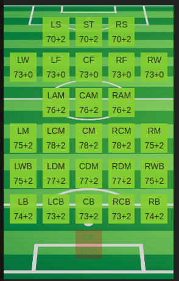

Classification of the player position on the field as noted on the sofifa.com web page

```r
knitr::include_graphics("team_positions.png")
```

We’ll copy the data so we preserve the original data.

```r
fifa19_copy = data.frame(fifa19)
tracemem(fifa19)==tracemem(fifa19_copy)
```

```
## [1] FALSE
```

```r
untracemem(fifa19_copy)
untracemem(fifa19_copy)
```

We change the “team_position” variable to a character type so we can manipulate it more easily.

```r
fifa19_copy['team_position'] <- sapply(fifa19_copy['team_position'], as.character);
```

Let’s create the right, left and central positions:

```r
# CREATING THE CENTRAL POSITIONS
for (column_name in c("ST","CF","CAM","CM","CDM","CB")){
  fifa19_copy$team_position[fifa19_copy$team_position == column_name] = "Central_positions";
}

# CREATING THE LEFT POSITIONS
for (column_name in c("LS","LW","LF","LAM","LM","LCM", "LWB", "LDM", "LB", "LCB")){
  fifa19_copy$team_position[fifa19_copy$team_position == column_name] = "Left_positions";
}

# CREATING THE RIGHT POSITIONS
for (column_name in c("RS","RF","RW","RAM", "RCM","RM", "RDM", "RWB", "RCB", "RB")){
  fifa19_copy$team_position[fifa19_copy$team_position == column_name] = "Right_positions";
}
```

We can use the function `table()` to get the contingency table for a single categorical variable.

```r
tbl = table(fifa19_copy$team_position)
print(tbl)
```

```
##
##                   Central_positions                GK    Left_positions
##               223              1065               642              2660
##               RES   Right_positions               SUB
##              2928              2659              7593
```

We remove the goalkeeper and substitute positions and check the joint contingency table for the position and preferred kicking foot variables.

```r
tbl = table(fifa19_copy[fifa19_copy$team_position == "Central_positions" | fifa19_copy$team_position == "Left_positions" | fifa19_copy$team_position == "Right_positions",]$team_position,
            fifa19_copy[fifa19_copy$team_position == "Central_positions" | fifa19_copy$team_position == "Left_positions" | fifa19_copy$team_position == "Right_positions",]$preferred_foot)
tbl
```

```
##
##                     Left Right
##   Central_positions  188   877
##   Left_positions    1180  1480
##   Right_positions    312  2347
```

Let’s add the row and column sums to the contingency tables.

```r
added_margins_tbl = addmargins(tbl)
print(added_margins_tbl)
```

```
##
##                     Left Right  Sum
##   Central_positions  188   877 1065
##   Left_positions    1180  1480 2660
##   Right_positions    312  2347 2659
##   Sum               1680  4704 6384
```

The $\chi^2$ test of independence is implemented in the `chisq.test()` function in R. The function takes a contingency table as its argument and tests the independence of the given variables.

The assumptions of the test is that the expected frequency of each class (category) is at least 5 (the `chisq.test()` function assumes this assumptions is satisfied, so we need to check it before running the test).

```r
for (col_names in colnames(added_margins_tbl)){
  for (row_names in rownames(added_margins_tbl)){
    if (!(row_names == 'Sum' | col_names == 'Sum') ){
      cat('Expected frequencies for class (category) ',col_names,'-',row_names,': ',(added_margins_tbl[row_names,'Sum'] * added_margins_tbl['Sum',col_names]) / added_margins_tbl['Sum','Sum'],'\n')
    }
  }
}
```

```
## Expected frequencies for class (category)  Left - Central_positions :  280.2632
## Expected frequencies for class (category)  Left - Left_positions :  700
## Expected frequencies for class (category)  Left - Right_positions :  699.7368
## Expected frequencies for class (category)  Right - Central_positions :  784.7368
## Expected frequencies for class (category)  Right - Left_positions :  1960
## Expected frequencies for class (category)  Right - Right_positions :  1959.263
```

Since all the expected frequencies are bigger than 5, we can continue with the $\chi^2$ test and check if the position of a player is independent of its preferred kicking foot.

```r
chisq.test(tbl,correct=F)
```

```
##
##  Pearson's Chi-squared test
##
## data:  tbl
## X-squared = 779.5, df = 2, p-value < 2.2e-16
```

There are several other interesting questions that you can further explore:

1. Is the position of the player on the field independent of its physical type?
2. Are defenders better in controlling the ball (“skill_ball_control”) than the attackers?
3. Are defenders better dribblers (“dribbling”) than attackers?